# Пример рекомендательной системы

Сегодня мы рассмотрим пример построения небольшой рекомендательной системы в R.

Используем пакет `recommenderlab`

```r
library(recommenderlab)
```

Построим систему, которая будет рекомендовать фильмы на основе базы оценок. В качестве исходных данных используем датасет MovieLense

```r
data(MovieLense)
MovieLense
```

```
## 943 x 1664 rating matrix of class 'realRatingMatrix' with 99392 ratings.
```

Каждая строчка соответствует пользователю, столбец – фильму, на пересечении – оценки. Однако в полной матрице 943*1664 было бы слишком много пропущенных значений (каждый пользователь оценивает существенно меньше фильмов, чем есть в датасете). Поэтому используется более компактный способ хранения.

*Обратите внимание* – датасет хранится в объекте класса realRatingMatrix, а не data.frame или matrix. Поэтому есть особенности работы с такими данными, например, ряд специальных функций именно для рекомендательных систем.

Для построения рекомендаций применим метод коллаборативной фильтрации. Этот метод основан на использовании оценок «похожих» людей. Похожесть (similarity) может определяться разными способами

- Коэффициент Пирсона;
- Косинусное расстояние;
- Евклидово расстояние.

Рассмотрим, например, похожесть первых 10 пользователей

```r
similarity_users10 <- similarity(MovieLense[1:10, ], method = "cosine", which = "users")
as.matrix(similarity_users10)
```

```
##             1          2          3          4          5          6
## 1  0.00000000 0.16893670 0.03827203 0.06634975 0.37967009 0.42968246
## 2  0.16893670 0.00000000 0.09706862 0.15310468 0.07362338 0.24210639
## 3  0.03827203 0.09706862 0.00000000 0.33343036 0.02200430 0.06017539
## 4  0.06634975 0.15310468 0.33343036 0.00000000 0.03268542 0.05730374
## 5  0.37967009 0.07362338 0.02200430 0.03268542 0.00000000 0.23863583
## 6  0.42968246 0.24210639 0.06017539 0.05730374 0.23863583 0.00000000
## 7  0.44048658 0.10867688 0.06368331 0.09410511 0.37498291 0.49185063
## 8  0.32007948 0.10425672 0.08603051 0.19327073 0.24892997 0.20251387
## 9  0.07838506 0.16246959 0.06322298 0.10408973 0.05684700 0.18499701
## 10 0.37773263 0.16127340 0.06748118 0.06254540 0.20142701 0.55485085
##             7          8          9         10
## 1  0.44048658 0.32007948 0.07838506 0.37773263
## 2  0.10867688 0.10425672 0.16246959 0.16127340
## 3  0.06368331 0.08603051 0.06322298 0.06748118
## 4  0.09410511 0.19327073 0.10408973 0.06254540
## 5  0.37498291 0.24892997 0.05684700 0.20142701
## 6  0.49185063 0.20251387 0.18499701 0.55485085
## 7  0.00000000 0.28600538 0.14618947 0.48882709
## 8  0.28600538 0.00000000 0.08594195 0.23328945
## 9  0.14618947 0.08594195 0.00000000 0.19822253
## 10 0.48882709 0.23328945 0.19822253 0.00000000
```

Или в виде графика (уже рассмотренной ранее heatmap)

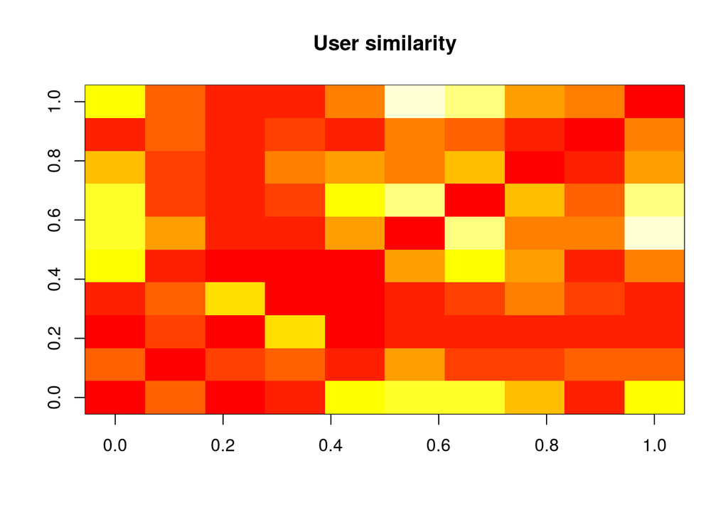

```r
image(as.matrix(similarity_users10), main = "User similarity")
```

Таким же образом можно посчитать и схожесть между фильмами

### Построение рекомендательной модели

Сначала подготовим данные, в частности, уберем те, что являются нерелевантными.

Если фильм редкий, его мало кто видел, то оценки для него могут быть сильно смщенными. Так же и для пользователя – если он оценил малое число фильмов, то ему сложно дать рекомендацию.

Как определить, что является “малым числом”? В общем случае – итерационно, т.е. отбираем данные, строим модель, оцениваем ее и так несколько раз. В данном примере рассмотрим только один шаг – будем считать, что нас интересуют фильмы с не менее 100 оценками и пользователи, поставившие не менее 50 оценок.

Количество оценок у фильма можно посчитать с помощью функции colCounts(), а количество оценок, поставленных одним пользователем – с помощью rowCounts(). Эти функции не учитывают 0, которыми обозначены отстутствющие оценки.

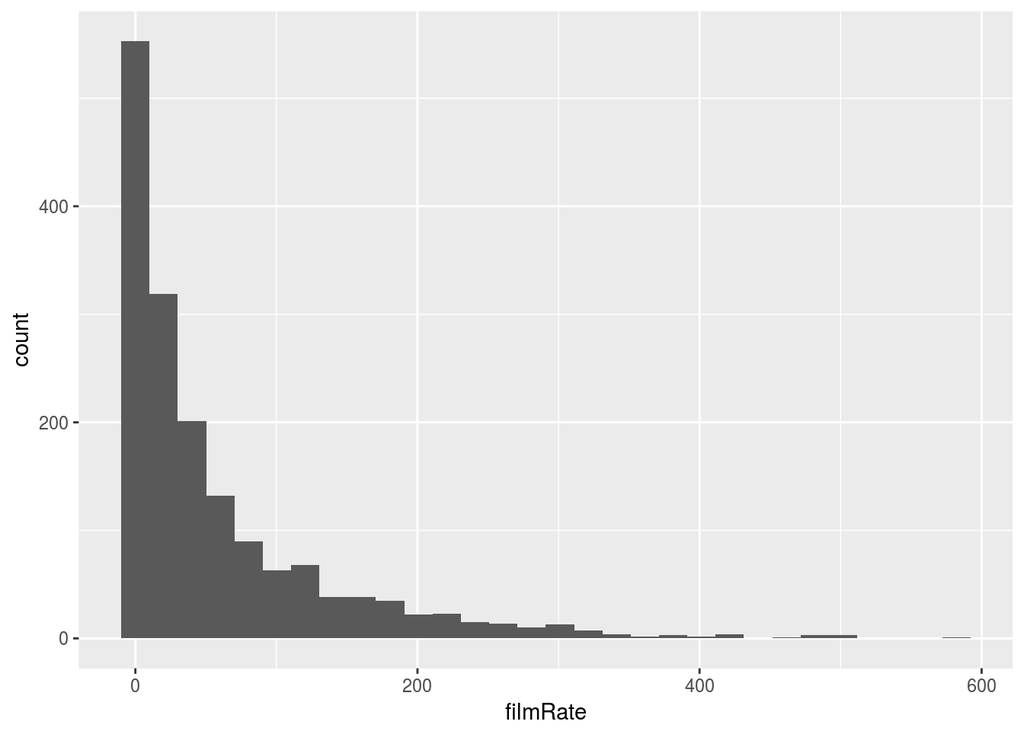

```r
library(ggplot2)
ggplot(data = data.frame(filmRate=colCounts(MovieLense))) + geom_histogram(aes(x=filmRate))
```

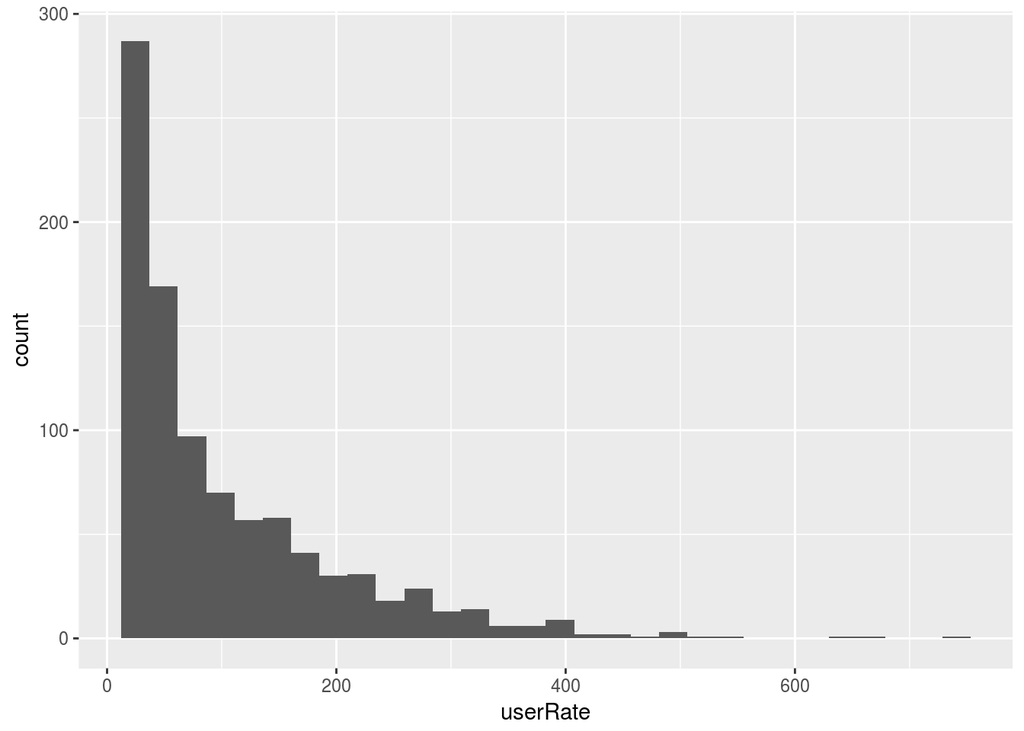

```r
ggplot(data = data.frame(userRate=rowCounts(MovieLense))) + geom_histogram(aes(x=userRate))
```

Отберем только строки и столбцы с нужным количеством оценок

```r
ratings_movies <- MovieLense[rowCounts(MovieLense) > 50,
colCounts(MovieLense) > 100]
ratings_movies
```

```
## 560 x 332 rating matrix of class 'realRatingMatrix' with 55298 ratings.
```

Рассмотрим распределение средних оценок пользователя

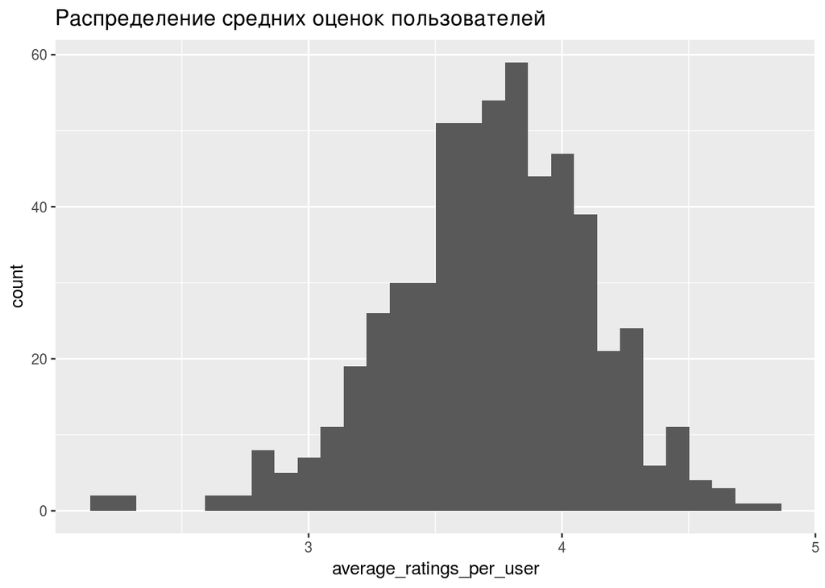

```r
average_ratings_per_user <- rowMeans(ratings_movies)
ggplot()+geom_histogram(aes(x=average_ratings_per_user)) +
ggtitle("Распределение средних оценок пользователей")
```

Метод коллаборативной фильтрации

- вычислить похожесть всех пар фильмов
- для каждого фильма найти k наиболее похожих
- для каждого пользователя определить фильмы, наиболее близкие к тем, которые он оценил

Разделим данные на тестовую и обучающую выборки. На обучающей построим модель, для пользователей из тестовой будем рекомендовать фильмы.

```r
set.seed(100)
test_ind <- sample(1:nrow(ratings_movies), size = nrow(ratings_movies)*0.2)
recc_data_train <- ratings_movies[-test_ind, ]
recc_data_test <- ratings_movies[test_ind, ]
```

Возможны разные методы построения модели. Рассмотрим метод IBCF (“Recommender based on item-based collaborative filtering (real data).”)

Параметры этого метода по умолчанию

```r
recommender_models <- recommenderRegistry$get_entries(dataType =
"realRatingMatrix")
recommender_models$IBCF_realRatingMatrix$parameters
```

```
## $k
## [1] 30
##
## $method
## [1] "Cosine"
##
## $normalize
## [1] "center"
##
## $normalize_sim_matrix
## [1] FALSE
##
## $alpha
## [1] 0.5
##
## $na_as_zero
## [1] FALSE
```

Построим рекомендательную модель

```r
recc_model <- Recommender(data = recc_data_train, method = "IBCF",
parameter = list(k = 30))
recc_model
```

```
## Recommender of type 'IBCF' for 'realRatingMatrix'
## learned using 448 users.
```

Детали этой модели можно получить с помощью метода getModel(), например, матрицу схожести

```r
model_details <- getModel(recc_model)
model_details$description
```

```
## [1] "IBCF: Reduced similarity matrix"
```

```r
model_details$sim[1:5, 1:5]
```

```
## 5 x 5 sparse Matrix of class "dgCMatrix"
##                       Toy Story (1995) GoldenEye (1995) Get Shorty (1995)
## Toy Story (1995)                     .                .                 .
## GoldenEye (1995)                     .                .                 .
## Get Shorty (1995)                    .                .                 .
## Twelve Monkeys (1995)                .                .                 .
## Babe (1995)                          .                .                 .
##                       Twelve Monkeys (1995) Babe (1995)
## Toy Story (1995)                          .           .
## GoldenEye (1995)                          .           .
## Get Shorty (1995)                         .           .
## Twelve Monkeys (1995)                     .           .
## Babe (1995)                               .           .
```

Рекомендации

- для каждого пользователя извлекаются те фильмы, которые он оценил
- для каждого из фильмов находятся похожие фильмы
- затем фильмы упорядочиваются согласно весам, где вес каждой рекомендации (фильма) вычисляется на основе оценок пользователя и показателей схожести фильмов (взвешенная сумма)

```r
recc_predicted <- predict(object = recc_model, newdata = recc_data_test, n = 6)
recc_predicted
```

```
## Recommendations as 'topNList' with n = 6 for 112 users.
```

Посмотрим на результат

```r
str(recc_predicted)
```

```
## Formal class 'topNList' [package "recommenderlab"] with 4 slots
##   ..@ items     :List of 112
##   .. ..$ 292: int [1:6] 312 8 55 107 13 99
##   .. ..$ 250: int [1:6] 120 193 310 118 75 45
##   .. ..$ 497: int [1:6] 197 30 201 114 158 193
##   .. ..$ 54 : int [1:6] 5 28 46 70 71 78
##   .. ..$ 426: int [1:6] 3 93 318 193 170 257
##   .. ..$ 440: int [1:6] 10 16 20 21 34 46
##   .. ..$ 749: int [1:6] 273 44 259 169 257 201
##   .. ..$ 334: int [1:6] 120 259 258 256 102 242
##   .. ..$ 488: int [1:6] 81 196 24 88 302 303
##   .. ..$ 160: int [1:6] 71 296 173 102 294 228
##   .. ..$ 551: int [1:6] 271 298 266 118 13 101
##   .. ..$ 821: int [1:6] 44 46 48 50 73 75
##   .. ..$ 264: int [1:6] 12 23 30 35 39 41
##   .. ..$ 360: int [1:6] 243 107 22 101 261 70
##   .. ..$ 683: int [1:6] 5 57 92 93 97 98
##   .. ..$ 588: int [1:6] 253 48 248 102 73 158
##   .. ..$ 193: int [1:6] 93 111 260 272 264 261
##   .. ..$ 323: int [1:6] 226 236 277 109 271 1
##   .. ..$ 916: int [1:6] 69 193 173 118 257 256
##   .. ..$ 608: int [1:6] 143 222 304 313 206 316
##   .. ..$ 470: int [1:6] 15 48 72 83 100 109
##   .. ..$ 625: int [1:6] 248 50 240 93 263 75
##   .. ..$ 911: int [1:6] 9 60 214 288 223 86
##   .. ..$ 655: int [1:6] 102 120 75 91 263 261
##   .. ..$ 373: int [1:6] 26 165 198 45 1 256
##   .. ..$ 158: int [1:6] 57 73 113 228 253 112
##   .. ..$ 669: int [1:6] 324 67 261 266 228 73
##   .. ..$ 786: int [1:6] 20 260 237 84 277 211
##   .. ..$ 476: int [1:6] 30 48 61 71 73 75
##   .. ..$ 254: int [1:6] 230 318 198 54 294 69
##   .. ..$ 423: int [1:6] 4 5 28 44 46 70
##   .. ..$ 831: int [1:6] 231 235 286 311 109 94
##   .. ..$ 308: int [1:6] 193 253 158 216 76 111
##   .. ..$ 848: int [1:6] 39 79 153 167 172 231
##   .. ..$ 591: int [1:6] 279 193 118 258 237 71
##   .. ..$ 776: int [1:6] 303 119 130 199 76 230
##   .. ..$ 161: int [1:6] 217 196 315 213 288 318
##   .. ..$ 533: int [1:6] 173 41 272 199 95 259
```

[output cut: 150 more lines]

```
##   .. ..$ 201: num [1:6] 3.96 3.89 3.87 3.86 3.82 ...
##   .. ..$ 246: num [1:6] 4.82 4.7 4.69 4.68 4.67 ...
##   .. ..$ 553: num [1:6] 5 5 5 5 5 5
##   .. ..$ 705: num [1:6] 5 5 5 5 4.85 ...
##   .. ..$ 174: num [1:6] 5 5 5 5 5 5
##   .. ..$ 286: num [1:6] 4.62 4.45 4.41 4.37 4.36 ...
##   .. ..$ 343: num [1:6] 4.96 4.89 4.88 4.83 4.76 ...
##   .. ..$ 697: num [1:6] 5 5 5 5 5 5
##   .. ..$ 303: num [1:6] 5 4.96 4.96 4.94 4.93 ...
##   .. ..$ 394: num [1:6] 5 5 5 5 5 5
##   .. ..$ 91 : num [1:6] 5 4.8 4.68 4.66 4.62 ...
##   .. ..$ 16 : num [1:6] 5 5 5 5 5 5
##   .. .. [list output truncated]
##   ..@ itemLabels: chr [1:332] "Toy Story (1995)" "GoldenEye (1995)" "Get Shorty (1995)" "Twelve Monkeys (1995)" ...
##   ..@ n         : int 6
```

Слоты (доступ через символ @)

- items – содержит индексы рекомендованных фильмов для каждого пользователя
- itemLabels – названия фильмов
- ratings – рейтинги рекомендаций
- n – число рекомендаций

Рекомендации для первого пользователя

```r
recc_user_1 <- recc_predicted@items[[1]]
recc_user_1
```

```
## [1] 312   8  55 107  13  99
```

```r
movies_user_1 <- recc_predicted@itemLabels[recc_user_1]
movies_user_1
```

```
## [1] "Philadelphia (1993)"
## [2] "Usual Suspects, The (1995)"
## [3] "Dances with Wolves (1990)"
## [4] "Psycho (1960)"
## [5] "Taxi Driver (1976)"
## [6] "Good, The Bad and The Ugly, The (1966)"
```

Общая матрица рекомендаций для пользователей

```r
recc_matrix <- sapply(recc_predicted@items, function(x){
colnames(ratings_movies)[x]
})
dim(recc_matrix)
```

```
## [1]   6 112
```

**Ваша очередь:**

Постройте рекомендательную систему на основе схожести между пользователями, а не между фильмами (метод UBCF вместо IBCF).